# Mixed Model

C. M. Ciafre

September 17, 2019

### Background

I collected plant species data from 24 wetland sites across the Eastern Highland Rim ecoregion once in early summer and once in late summer. Each site was subsampled with a varying number of 1 m^2 quadrats, resulting in 923 subsamples.

Fixed effects: -Sampling season (early or late) -Water permanence status (ephemeral or permanent) -Site size class (small or medium or large)

Random effects: -Plot -Quadrat

### Two ways to visualize trends in the data

We can visualize all the quadrats at once and see if sampling season and water permanence affect quadrat level richness… (Note that sampling effort was halved for the late season to save time)

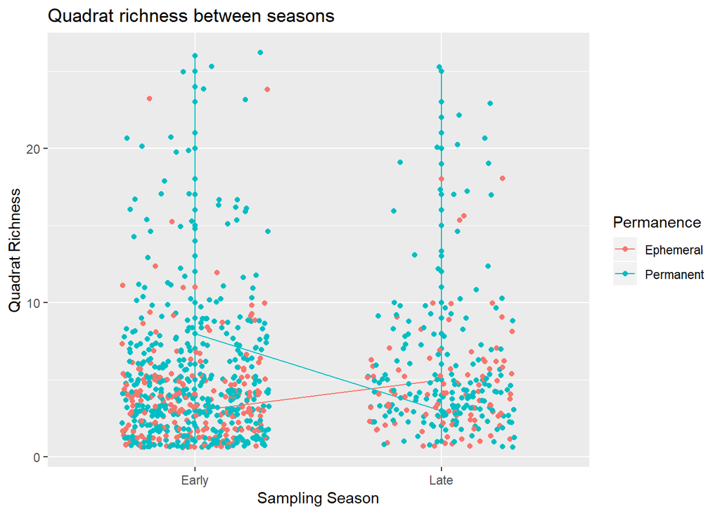

Or we can examine the effects of season on each site using mean quadrat richness…

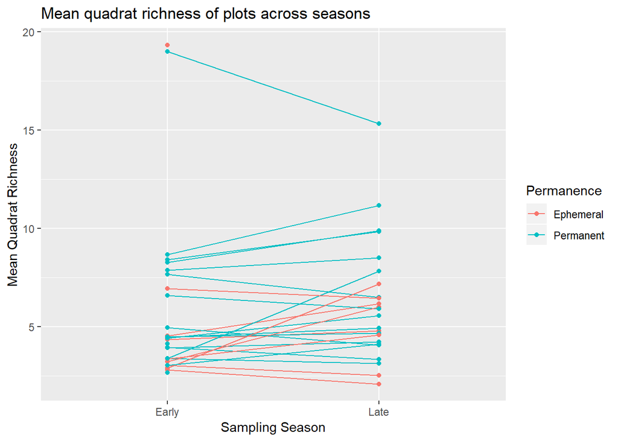

It also appears that site size has an effect on mean quadrat richness… (I used size classes rather than site radius to make things simpler)

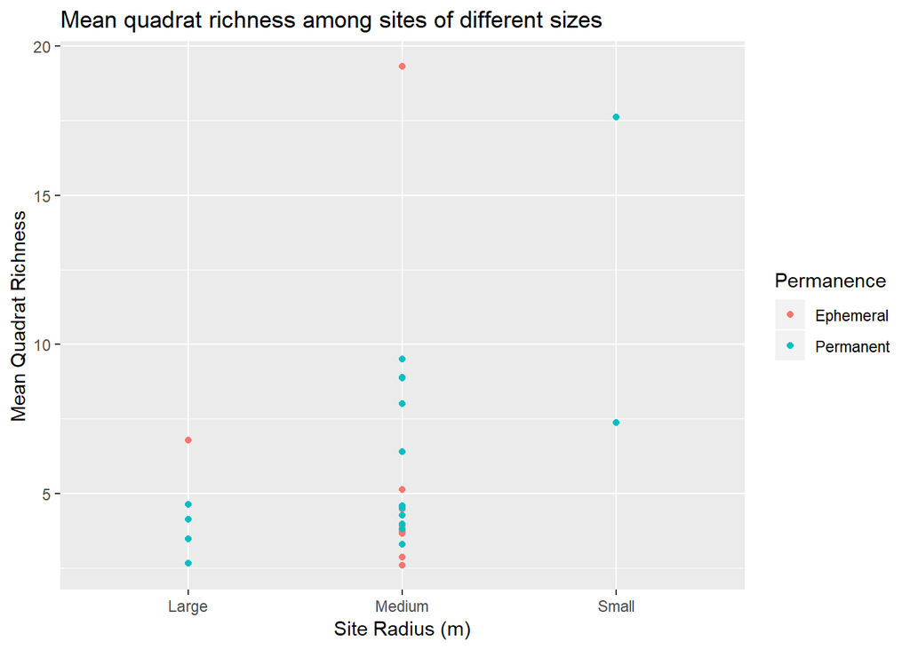